# Practical Machine Learning Project

Johan Frisk

November 20, 2015

# Introduction

This is the analysis of a dataset provided by [Groupware@LES](http://groupware.les.inf.puc-rio.br/har) as a part of the Coursera course in Practical Machine Learning given by John Hopkins Bloomberg School of Public Health, as a part of the Data Scientist Specialization.

The challenge is to develop a model which can distinguish between correct and incorrect execution of Dumbbell Bicep Curls according to the table below.

- Class A: exactly according to the specification
- Class B: throwing the elbows to the front
- Class C: lifting the dumbbell only halfway
- Class D: lowering the dumbbell only halfway
- Class E: throwing the hips to the front

## Data

The dataset includes readings from belt, forearm, arm, and dumbbell accelerometers, it is split into a training and a test data set.

## Method

```r
# loading required libraries --------------------------------------------------
library(caret)
library(ggplot2)
library(gbm)
library(dplyr) # must be loaded after plyr in the caret package
```

##### Loading and cleaning the data

```r
# reading in the data ---------------------------------------------------------
train <- read.csv("./data/pml-training.csv",
                  na.strings = "NA",
                  strip.white = TRUE)
train <- tbl_df(train)

eval <- read.csv("./data/pml-testing.csv",
                  na.strings = "NA",
                  strip.white = TRUE)
eval <- tbl_df(eval)
```

##### Creating a training and testing data set

Two data partitions are created, the first for training the model and a smaller for testing the accuracy.

```r
# splitting the training set into train and test ------------------------------
set.seed(123)
inTrain <- createDataPartition(y=train$classe, p=0.9, list=FALSE)
training <- train[inTrain,]
testing <- train[-inTrain,]
```

##### Fitting a model

```r
# fit a boosted tree model via the gbm package --------------------------------
gbmFit <- train(classe ~ user_name +
                        pitch_arm +
                        yaw_arm +
                        roll_arm +
                        roll_belt +
                        pitch_belt +
                        yaw_belt +
                        gyros_belt_x +
                        gyros_belt_y +
                        gyros_belt_z +
                        accel_belt_x +
                        accel_belt_y +
                        accel_belt_z +
                        magnet_belt_x +
                        magnet_belt_y +
                        magnet_belt_z +
                        gyros_arm_x +
                        gyros_arm_y +
                        gyros_arm_z +
                        accel_arm_x +
                        accel_arm_y +
                        accel_arm_z +
                        magnet_arm_x +
                        magnet_arm_y +
                        magnet_arm_z +
                        roll_dumbbell +
                        pitch_dumbbell +
                        yaw_dumbbell,
                method="gbm",
                data=training,
                verbose=FALSE)
```

```r
gbmFit
```

```
## Stochastic Gradient Boosting
##
## 17662 samples
##   159 predictor
##     5 classes: 'A', 'B', 'C', 'D', 'E'
##
## No pre-processing
## Resampling: Bootstrapped (25 reps)
## Summary of sample sizes: 17662, 17662, 17662, 17662, 17662, 17662, ...
## Resampling results across tuning parameters:
##
##   interaction.depth  n.trees  Accuracy   Kappa      Accuracy SD
##   1                   50      0.6561816  0.5618079  0.005796258
##   1                  100      0.7076391  0.6288331  0.005215333
##   1                  150      0.7447894  0.6765873  0.005099116
##   2                   50      0.7659551  0.7035139  0.005622495
##   2                  100      0.8350394  0.7912101  0.004873226
##   2                  150      0.8693000  0.8345515  0.003953933
##   3                   50      0.8293722  0.7840353  0.006187399
##   3                  100      0.8876842  0.8578182  0.003638447
##   3                  150      0.9144266  0.8917117  0.002682595
##   Kappa SD
##   0.007340410
##   0.006590833
##   0.006473137
##   0.007070387
##   0.006179776
##   0.005014407
##   0.007796944
##   0.004620510
##   0.003406644
##
## Tuning parameter 'shrinkage' was held constant at a value of 0.1
##
## Tuning parameter 'n.minobsinnode' was held constant at a value of 10
## Accuracy was used to select the optimal model using  the largest value.
## The final values used for the model were n.trees = 150,
##  interaction.depth = 3, shrinkage = 0.1 and n.minobsinnode = 10.
```

## Using the model to predict on training data

The derived model is applied on the training data and we expect a high accuracy since the same data is used for training and prediction.

```r
# predict the results using the training data ---------------------------------
predictTree <- predict(gbmFit,training)
tbl1 <- xtabs(~predictTree + training$classe)
tbl1
```

```
##            training$classe
## predictTree    A    B    C    D    E
##           A 4736  148   47   36   37
##           B   77 3149  126   16   32
##           C   70   95 2829  138   25
##           D  104    7   63 2681   23
##           E   35   19   15   24 3130
```

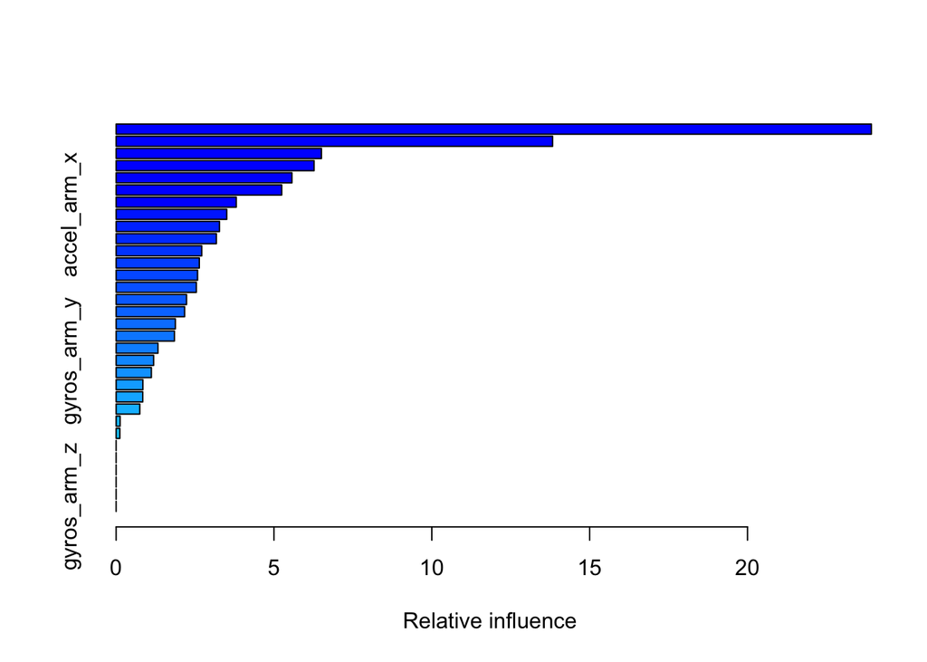

```
##                                 var    rel.inf
## roll_belt                 roll_belt 23.9246872
## yaw_belt                   yaw_belt 13.8268623
## magnet_belt_z         magnet_belt_z  6.5032451
## roll_dumbbell         roll_dumbbell  6.2708400
## pitch_belt               pitch_belt  5.5692851
## magnet_arm_x           magnet_arm_x  5.2454988
## magnet_arm_z           magnet_arm_z  3.8056788
## accel_arm_x             accel_arm_x  3.5037625
## gyros_belt_z           gyros_belt_z  3.2736606
## roll_arm                   roll_arm  3.1750331
## user_nameeurico     user_nameeurico  2.7116763
## pitch_dumbbell       pitch_dumbbell  2.6350535
## yaw_dumbbell           yaw_dumbbell  2.5797226
## accel_arm_z             accel_arm_z  2.5401671
## yaw_arm                     yaw_arm  2.2303546
## accel_belt_z           accel_belt_z  2.1689258
## magnet_belt_x         magnet_belt_x  1.8770178
## pitch_arm                 pitch_arm  1.8459257
## magnet_arm_y           magnet_arm_y  1.3258120
## gyros_arm_y             gyros_arm_y  1.1871712
## magnet_belt_y         magnet_belt_y  1.1161741
## user_namecharles   user_namecharles  0.8477371
## gyros_arm_x             gyros_arm_x  0.8429132
## gyros_belt_y           gyros_belt_y  0.7491967
## accel_arm_y             accel_arm_y  0.1266720
## gyros_belt_x           gyros_belt_x  0.1169266
## user_namecarlitos user_namecarlitos  0.0000000
## user_namejeremy     user_namejeremy  0.0000000
## user_namepedro       user_namepedro  0.0000000
## accel_belt_x           accel_belt_x  0.0000000
## accel_belt_y           accel_belt_y  0.0000000
## gyros_arm_z             gyros_arm_z  0.0000000
```

```r
summary(gbmFit,n.trees=150)
```

```r
tbl1
```

```
##            training$classe
## predictTree    A    B    C    D    E
##           A 4736  148   47   36   37
##           B   77 3149  126   16   32
##           C   70   95 2829  138   25
##           D  104    7   63 2681   23
##           E   35   19   15   24 3130
```

```r
acc1 <- round(100*sum(diag(tbl1))/sum(tbl1),2) # accuracy of the prediction
acc1
```

```
## [1] 93.56
```

```r
confusionMatrix(predictTree, training$classe)
```

```
## Confusion Matrix and Statistics
##
##           Reference
## Prediction    A    B    C    D    E
##          A 4736  148   47   36   37
##          B   77 3149  126   16   32
##          C   70   95 2829  138   25
##          D  104    7   63 2681   23
##          E   35   19   15   24 3130
##
## Overall Statistics
##
##                Accuracy : 0.9356
##                  95% CI : (0.9319, 0.9392)
##     No Information Rate : 0.2843
##     P-Value [Acc > NIR] : < 2.2e-16
##
##                   Kappa : 0.9186
##  Mcnemar's Test P-Value : < 2.2e-16
##
## Statistics by Class:
##
##                      Class: A Class: B Class: C Class: D Class: E
## Sensitivity            0.9431   0.9213   0.9185   0.9261   0.9640
## Specificity            0.9788   0.9824   0.9775   0.9867   0.9935
## Pos Pred Value         0.9464   0.9262   0.8961   0.9315   0.9711
## Neg Pred Value         0.9774   0.9811   0.9827   0.9855   0.9919
## Prevalence             0.2843   0.1935   0.1744   0.1639   0.1838
## Detection Rate         0.2681   0.1783   0.1602   0.1518   0.1772
## Detection Prevalence   0.2833   0.1925   0.1787   0.1629   0.1825
## Balanced Accuracy      0.9609   0.9518   0.9480   0.9564   0.9788
```

##### Plotting the main results

From the summary table and graph we find that the two first variables have a very large impact on prediction. To see how good separation we would get by using only these two predictors we plot them against each other. From the graph we can see that significant overlaps remain and that this simple model is insufficient.

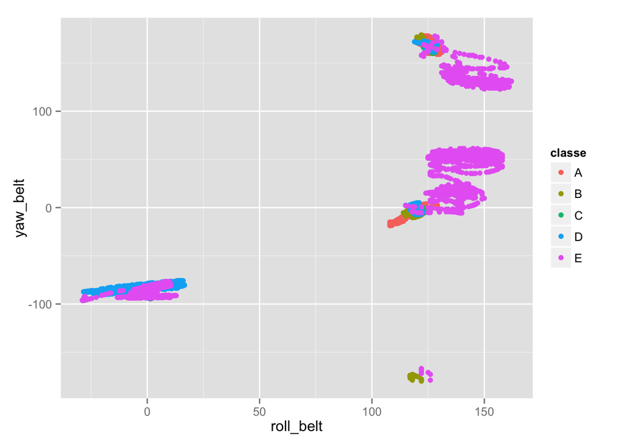

```r
# plot separation using only the two most influential predictors --------------
qplot(roll_belt, yaw_belt,colour=classe,data=training)
```

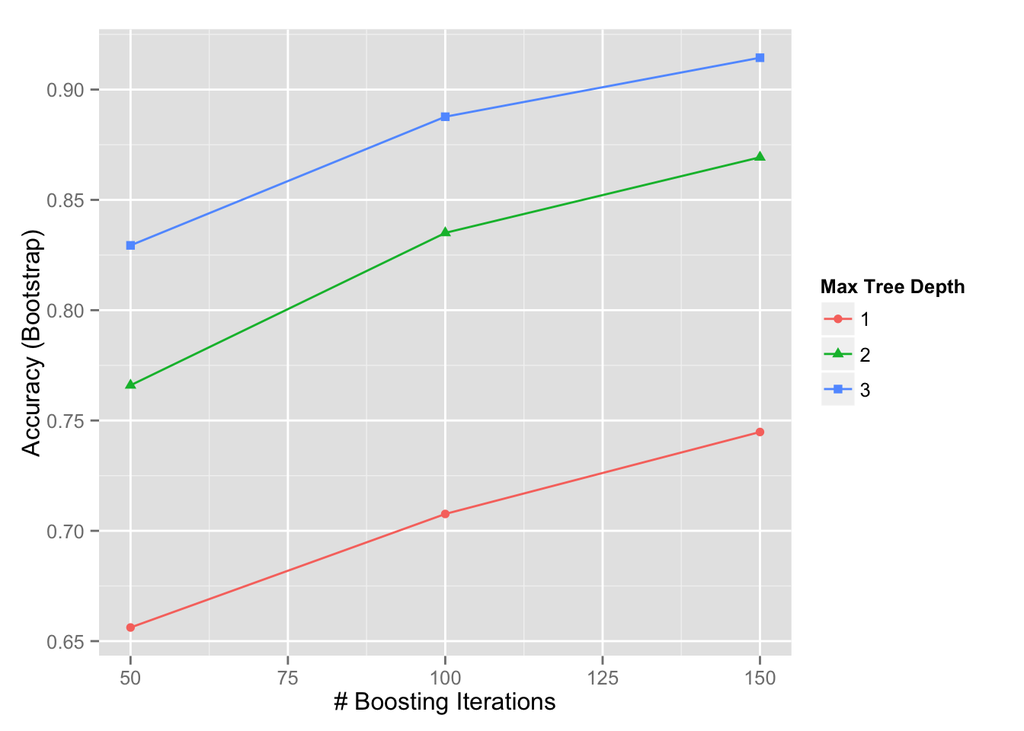

```r
# plot effectiveness of boosting and Tree Depth
ggplot(gbmFit)
```

## Using the model to predict on the testing data

After fitting the model and testing it on the same data it was built on, it is time to evaluate the accuracy on the testing set we set aside earlier. We expect the accuracy to be lower as was proven by the fact that it went from 93,6% to 92,2%.

```r
# predict the results using the testing data ----------------------------------
predictTreeTest <- predict(gbmFit,testing)
tbl2 <- xtabs(~predictTreeTest + testing$classe)
tbl2
```

```
##                testing$classe
## predictTreeTest   A   B   C   D   E
##               A 517  18   8   3   7
##               B   6 341  12   2   6
##               C   7  19 309  13   2
##               D  21   1   8 300   4
##               E   7   0   5   3 341
```

```r
acc2 <- round(100*sum(diag(tbl2))/sum(tbl2),2) # accuracy of the prediction
acc2
```

```
## [1] 92.24
```

```r
confusionMatrix(predictTreeTest, testing$classe)
```

```
## Confusion Matrix and Statistics
##
##           Reference
## Prediction   A   B   C   D   E
##          A 517  18   8   3   7
##          B   6 341  12   2   6
##          C   7  19 309  13   2
##          D  21   1   8 300   4
##          E   7   0   5   3 341
##
## Overall Statistics
##
##                Accuracy : 0.9224
##                  95% CI : (0.9097, 0.9339)
##     No Information Rate : 0.2847
##     P-Value [Acc > NIR] : < 2.2e-16
##
##                   Kappa : 0.902
##  Mcnemar's Test P-Value : 0.0008251
##
## Statistics by Class:
##
##                      Class: A Class: B Class: C Class: D Class: E
## Sensitivity            0.9265   0.8997   0.9035   0.9346   0.9472
## Specificity            0.9743   0.9836   0.9747   0.9793   0.9906
## Pos Pred Value         0.9349   0.9292   0.8829   0.8982   0.9579
## Neg Pred Value         0.9709   0.9761   0.9795   0.9871   0.9882
## Prevalence             0.2847   0.1934   0.1745   0.1638   0.1837
## Detection Rate         0.2638   0.1740   0.1577   0.1531   0.1740
## Detection Prevalence   0.2821   0.1872   0.1786   0.1704   0.1816
## Balanced Accuracy      0.9504   0.9416   0.9391   0.9569   0.9689
```

## Using the model to predict on the evaluation data

Finally, we apply the model to the evaluation data set provided by Coursera.

```r
# predict the results using the evaluation data ----------------------------------
answer<-predict(gbmFit,eval)
answer
```

```
##  [1] B A B A A E D B A A B C B A E E A B B B
## Levels: A B C D E
```

```r
# code as suggested by Coursera
pml_write_files = function(x){
        n = length(x)
        for(i in 1:n){
            filename = paste0("problem_id_",i,".txt")
            write.table(x[i],file=filename,quote=FALSE,row.names=FALSE,col.names=FALSE)
        }
    }

pml_write_files(answer)
```

After submitting the answers we find that the algorithm correctly predicted 20 out of 20 test cases.